# 8: mixed-effects regressions

## So far…

Regressions:

- How does outcome change, for a change in the predictor?
- how much have we learnt about the outcome, by learning something about the predictor?

Putting aside the list of assumptions, I focused on 2 main worries:

- Is the relationship linear? If no, generalized linear model
- Are the errors independent? If no, mixed-effects model

## Learning outcomes

- Understand the difference between fixed and random effects
- Understand why we bother modeling random effects
- Use the `lmer()` function to create a simple model
- Understand main elements of the `lmer()` output

## Ok, what is the motivation for this?

We’re trying to understand/explain something about the outcome

Tension: reduce unexplained variance vs. avoid overfitting/maintain generality

LMEMs can help with this! How?

## Simulate some data

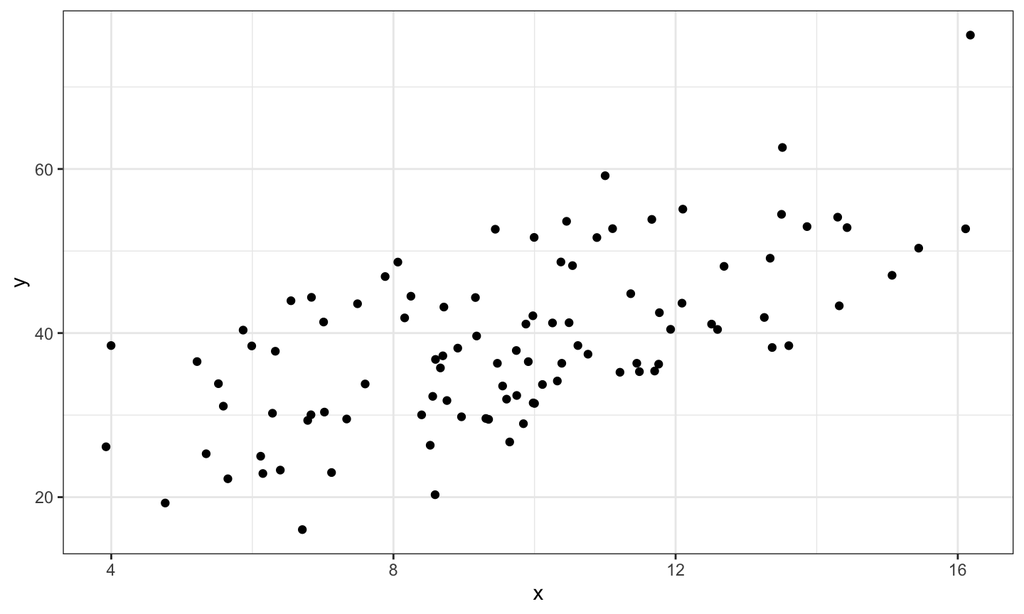

## Color by participant

What is going on here?

- What can we say about each subject?
- What does this mean for the overall residuals

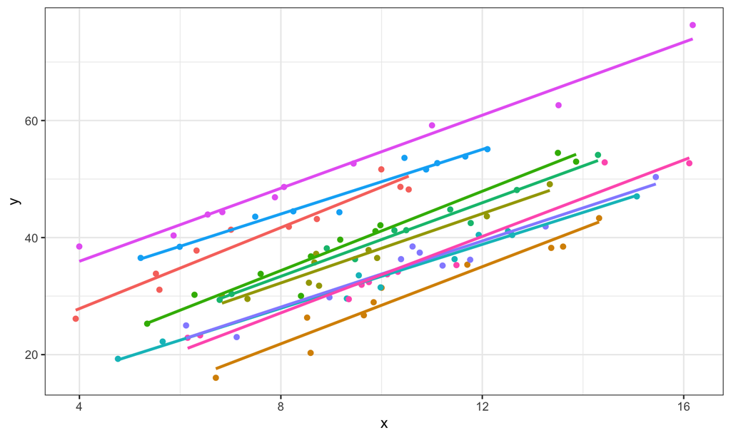

## How is this different from a (plain) lm?

- \(y = b_0 + b_1x_1 + .. + \epsilon\)
- This error is unstructured: it’s a big amorphous bag of stuff we don’t know
- But what if there is some structure to the residuals? E.g., residuals for each person are similar in some way
- One option? Aggregate data points by person
  - BUT then we’re losing information!
  - One aim here is to not throw out any information unnecessarily
- Another option? Explicitly include this structure (E.g., by person) in the model
  - So make sure it’s in long format
- \(y = b_0 + b_1x_1 + .. + u_0 + \epsilon\)

## Ok, so why is this not just like adding another predictor?

- It’s a random effect
- Do we know what determines why one person is doing better overall than another?
  - No, because if we did, we’d model *that* variable
  - But as it is, we don’t know/don’t care
  - We can’t control it/control for it
- It’s specific to this data:
  - if we did this with another 100 people, we’d get a different set of random intercepts

## What does this get us, in terms of understanding the study phenomenon?

How much have we added to the model (compared, say, to adding another fixed effect)?

What has it gained us?

## Let’s check the model outputs

```
##
## Call:
## lm(formula = y ~ x, data = dat_cc)
##
## Residuals:
##     Min      1Q  Median      3Q     Max
## -16.166  -6.431  -1.357   6.489  22.031
##
## Coefficients:
##             Estimate Std. Error t value Pr(>|t|)
## (Intercept)  16.2774     2.9018   5.609 1.88e-07 ***
## x             2.3495     0.2889   8.134 1.31e-12 ***
## ---
## Signif. codes:  0 '***' 0.001 '**' 0.01 '*' 0.05 '.' 0.1 ' ' 1
##
## Residual standard error: 7.974 on 98 degrees of freedom
## Multiple R-squared:  0.403,  Adjusted R-squared:  0.3969
## F-statistic: 66.16 on 1 and 98 DF,  p-value: 1.315e-12
```

## Let’s check the model outputs

(We’ll look at this syntax in more detail shortly)

```
## Linear mixed model fit by REML ['lmerMod']
## Formula: y ~ x + (1 | sub_id)
##    Data: dat_cc
##
## REML criterion at convergence: 469.1
##
## Scaled residuals:
##      Min       1Q   Median       3Q      Max
## -3.01528 -0.59297 -0.00207  0.70057  2.75282
##
## Random effects:
##  Groups   Name        Variance Std.Dev.
##  sub_id   (Intercept) 69.561   8.340
##  Residual              3.889   1.972
## Number of obs: 100, groups:  sub_id, 10
##
## Fixed effects:
##             Estimate Std. Error t value
## (Intercept)  9.19204    2.74374    3.35
## x            3.08307    0.07559   40.78
##
## Correlation of Fixed Effects:
##   (Intr)
## x -0.266
```

## Random intercepts vs random slopes

- So far we just had a random intercept (1|sub_id)
- But we could have a random slope, too.
  - Slope for what? Some or all of the main predictors
  - here: (1+x|subj_id)
- Look at the previous plot - does it look like the slopes (for y~x) vary much across participants?
- Add a random slope to the above model, and see what it looks like

## Re-simulate the data to see if we can generate random slopes

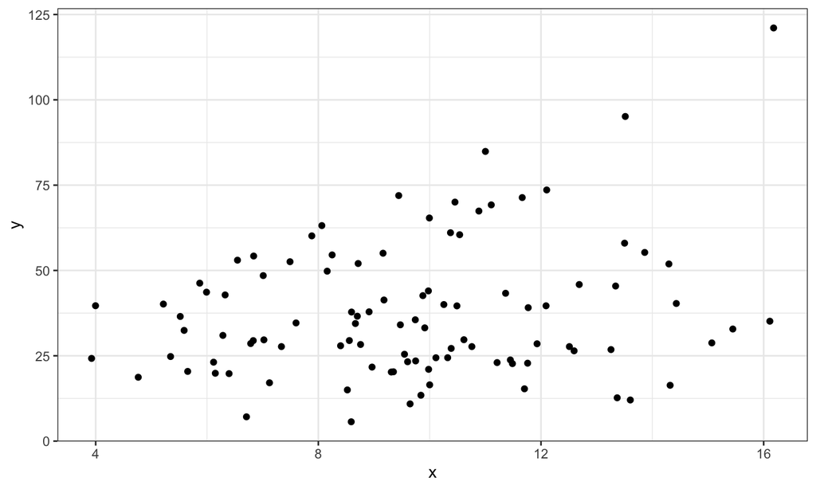

## Re-simulate the data to see if we can generate random slopes

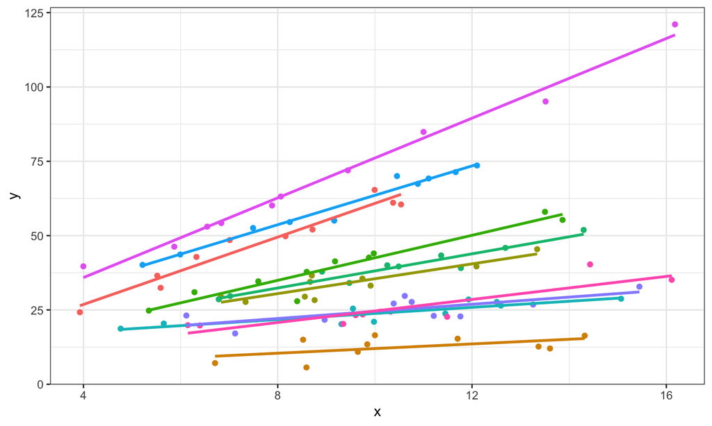

## Re-simulate the data to see if we can generate random slopes

Notice that the variance is heterogeneous. That’s ok!

Let’s run the regressions again (including a random slope in the lmer)

What, if anything, has changed?

## Possible random effects structures

- Commonly: subject, trial, classroom, etc.
- intercept only (1|subject), (1|trial)
- random slope too (1+x|subject), (1+x|trial)
- nested (1|class/subject)

## Choosing a random effects structure

There is conflicting advice on this:

Keep it simple vs keep it maximal

Bates, D., Kliegl, R., Vasishth, S., & Baayen, H. (2015). Parsimonious mixed models. arXiv preprint arXiv:1506.04967.

Barr, D. J., Levy, R., Scheepers, C., & Tily, H. J. (2013). Random effects structure for confirmatory hypothesis testing: Keep it maximal. Journal of Memory and Language, 68(3), 255–278. doi:10.1016/j.jml.2012.11.001

## Exercise

data: `awards.csv` (source: https://stats.idre.ucla.edu/r/faq/random-coefficient-poisson-models/

- outcome: awards
- main predictor: gender
- grouping variable: school (`cid`)
- Plot the data
- Decide what distribution family to specify
- Create a mixed-effects model
- Decide whether to include a random slope
- Use `predict` to understand how much of a difference

## Summarising benefits of lmer

- Reasonably robust against missing data/unbalanced designs
- Carefully weigh the benefits of a within-subjects design
  - vs. averaging or requiring independent observations
  - can take the full data into account
- Hierarchical: children in classes in schools in school districts
  - `(1|school/participant)`
- Can allow for quite complex models (if you *really* need such a thing)
- Very flexible. Can be generalized quite easily
  - E.g. if data not normally distributed

## Where are the p-values?!?!

- Psychology should wean itself off p-values
- The creators of lme4 decided not to include them, because they are unsure how to calculate DFs for these models
- BUT if you really want some, install/load package `lmerTest`

## Where are the p-values?!?!

- Much better: bootstrap CIs

```r
bootLmer <- function(.) {
  c(beta=fixef(.),
    sigma=sigma(.),
    sig01=sqrt(unlist(VarCorr(.))))
}

awards_boot <- bootMer(mod_awards,
                       bootLmer,
                       nsim = 1000)

awards_CIs <- boot.ci(awards_boot,
                      type="basic",
                      index=2) #row in model summary: fixed effects
```

## Resources:

- http://www.bodowinter.com/resources.html
- https://www.researchgate.net/publication/221995574_Generalized_Linear_Mixed_Models_A_Practical_Guide_for_Ecology_and_Evolution